# 1 A Unifying Perspective

Many of the concepts involved in linear regression can be understood as operations related to projection and change of basis. More broadly, linear regression can be viewed as an application of linear algebra in a vector space constructed from data. The model represents a linear relationship, and the least-squares solution corresponds to an orthogonal projection in a vector space. Concepts such as inner products, orthogonality, and change of basis provide the geometric foundation behind regression and related methods such as PCA. From this perspective, these techniques are not independent procedures, but different ways of operating on data within the same underlying structure. Connecting quantitative methods to their underlying principles and geometric meaning can significantly improve student understanding, particularly for students without a strong mathematical background. When visual explanations are used alongside formal definitions, students are better able to see what is being done to the data, why this operation is meaningful, and how it relates to the overall goals of data analysis. For this reason, selecting appropriate plots and visualizations throughout the course is essential for conveying these ideas clearly and intuitively.

# 2 Examples: Using Plots to Connect Methods with Their Purpose

## 2.1 Introducing Linear Algebra through Plots (Week 4)

For Week 4 (intro to linear algebra), rather than starting from matrix multiplication rules, it may be helpful to begin with a simple plot that visually shows the relationship between a matrix, a vector, and the vector space. Even with minimal explanation, such a visualization can make it easier for beginners to understand what a matrix operation does geometrically, and it also creates an early connection to linear regression by linking real-world data to feature representations.

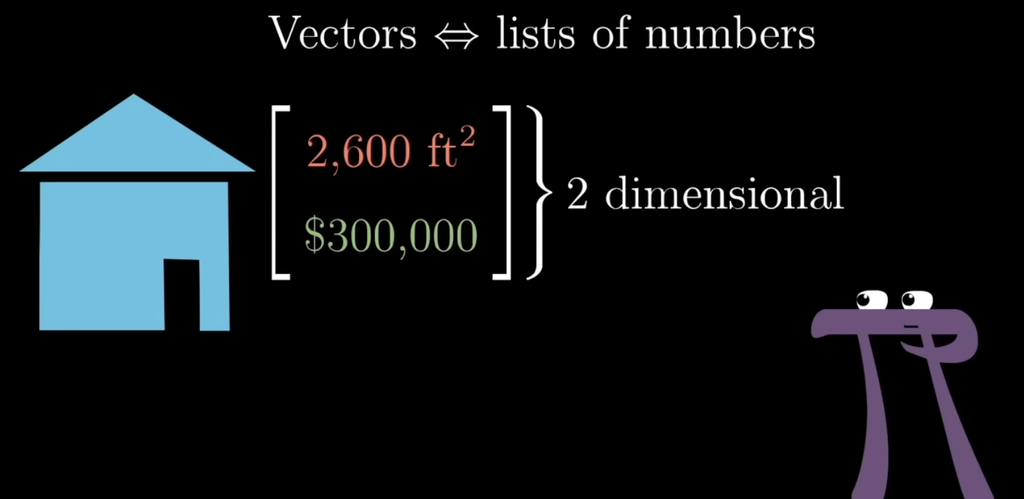

Figure 1: Feature

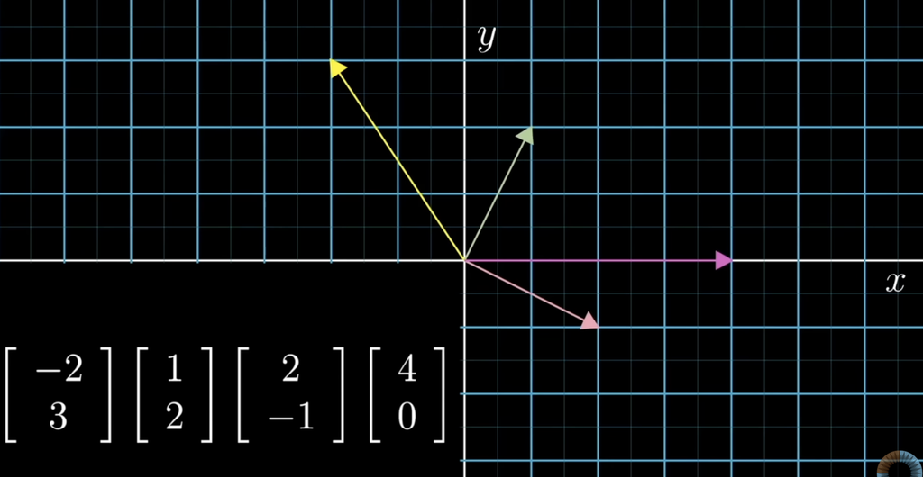

Figure 2: Matrix and vextor

*Source: Screenshot from 3Blue1Brown’s “Vectors, what even are they?” YouTube. https://www.youtube.com/watch?v=fNk_zzaMoSs*

For the transpose of a matrix, I think the *Essence of Linear Algebra* series by 3Blue1Brown (availiable at: https://www.youtube.com/watch?v=fNk_zzaMoSs&list=PLZHQObOWTQDPD3MizzM2xVFitgF8hE_ab) is a strong example of how visualization can support beginners in understanding the basic rules. Short clips or selected explanations could be included as additional resources (for example, via homework on a GitHub page), so students can revisit the intuition outside class time.

## 2.2 Measuring Relationships: Variance, Covariance, and Projection

For the next lecture on measuring relationships, where covariance is introduced, I suggest adding a simple vector-space graphic to show what “relationship” can look like geometrically. If we treat features in a dataset as vectors, then the direction of these vectors becomes meaningful: when two vectors point in similar directions, one has a non-zero projection on the other, which can be interpreted as being “related” in a way that feels intuitive.

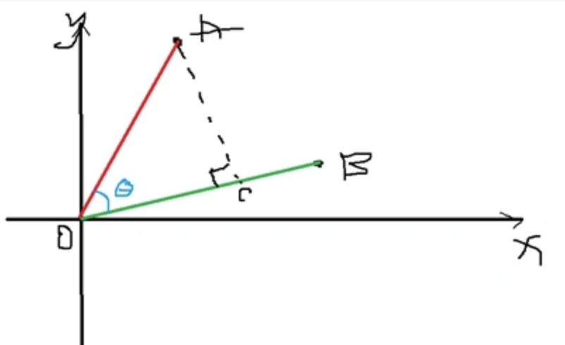

This also provides a clear bridge to a key rule: if two vectors are orthogonal, the projection value is zero. This idea not only helps students understand covariance more naturally, but also connects to the reason why we often prefer orthogonal directions when representing data—an idea that later echoes with the covariance matrix and PCA.

These points may look like basic information, but they are worth emphasizing. It is easy to assume students have fully understood these ideas after seeing them once, but what matters here is not just the definitions, but the general principle behind them: in analysis and in planning, we often want information to be neatly separated just like orthogonal vectors.

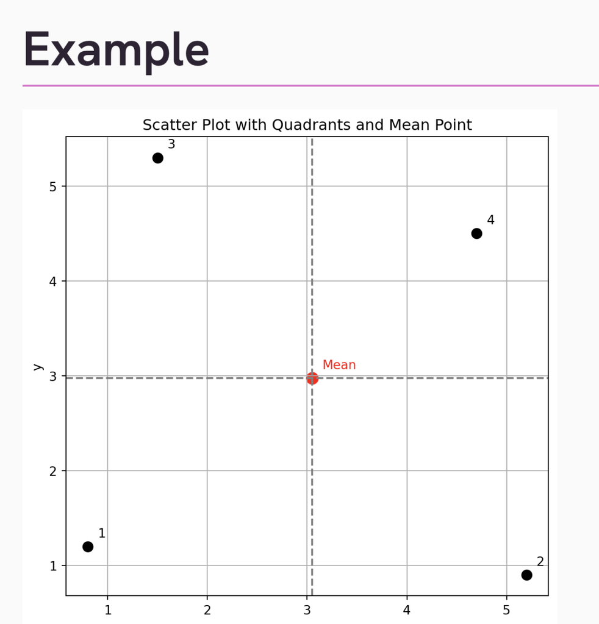

Figure 4: Scatter plot from week4

For the plot used when introducing covariance and correlation, the visualization shows the use of the mean value but may not fully communicate why we use it (figure). A simple framing such as “We care about change, not absolute position”, along with an example where x and y change almost perfectly in sync but have very different absolute numerical levels—can help students understand how mean-centering affects measurement and analysis. This helps students relate real-world data behavior to the statistical method, and shapes how they interpret these concepts.

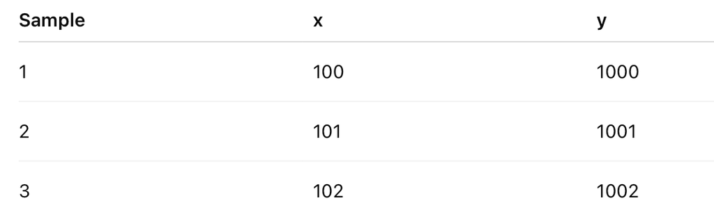

Figure 5: Standardization

## 2.3 PCA: Aligning the Method with the Data Processing Goal

For PCA, a plot similar to Figure 6 can also be effective. If the variables are scattered mainly along one dominant direction, that direction corresponds to PC1. This makes it intuitive that PC1 “carries” the most information, because the main changes in the data occur along that direction. In contrast, the original basis directions (such as x1 and x2) may not align with where the variation actually lies.

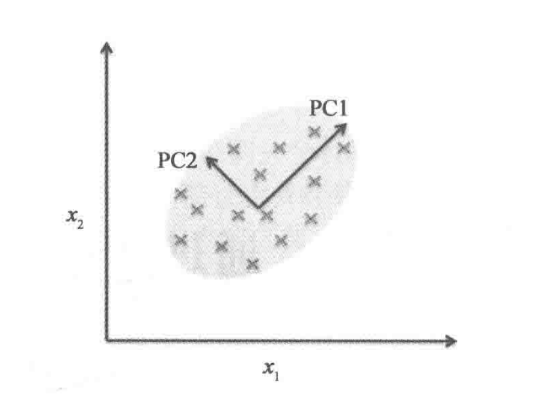

Figure 6: PCA

*Source: Raschka, S. (2015). Python Machine Learning. Packt Publishing.*

From the perspective of correlation and representation, we want a new set of basis vectors that are orthogonal and more aligned with how the data vary. For multi-dimensional data, the direction that carries the second most information while remaining orthogonal to PC1 becomes PC2. I think expanding the plot to a 3-dimensional example would be more suitable here, because it helps students see how the idea generalizes beyond 2D.

This is also where plots can make the selection rule very clear: we choose directions based on how much information they carry, and we keep the most informative ones. In other words, students can directly connect PCA to the goal of data processing: reducing the complexity of the data while maintaining most of its information at the same time.

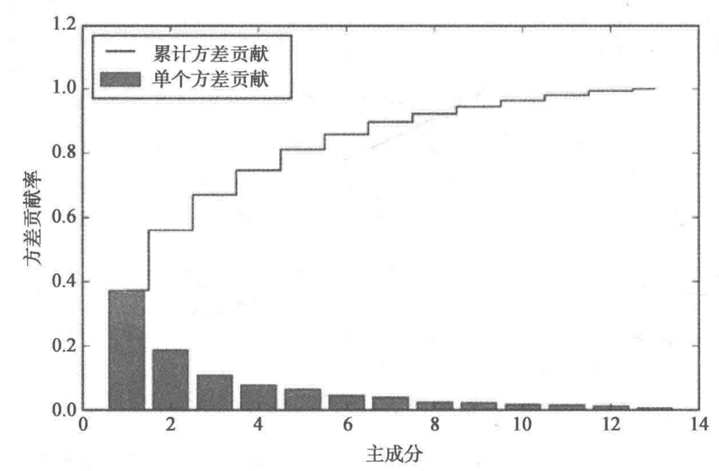

Figure 7: Principal Component

*Source: Raschka, S. (2015). Python Machine Learning. Packt Publishing.*

I also strongly recommend the animated visualization like this video:

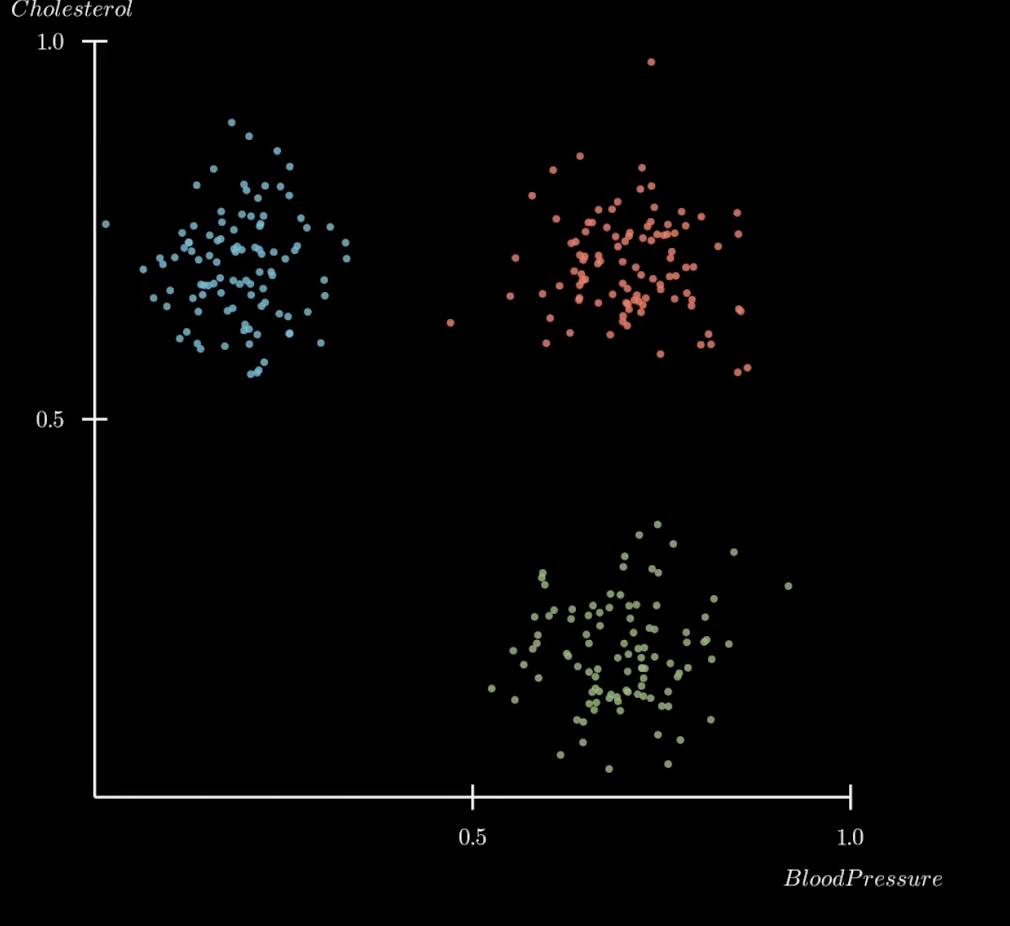

Figure 8 step1

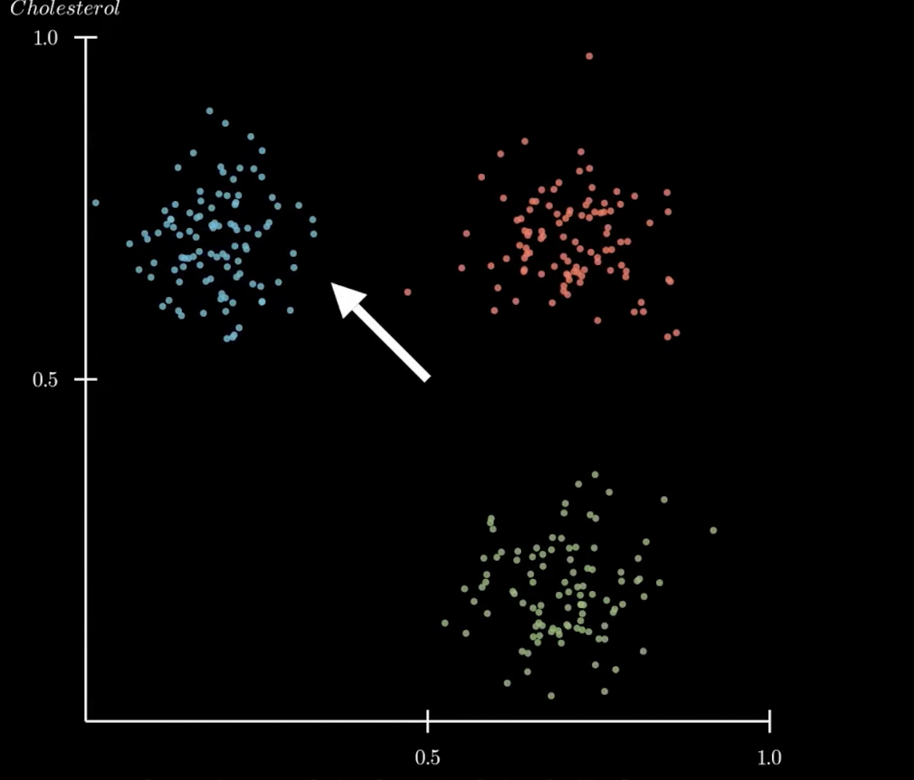

Figure 9 step2

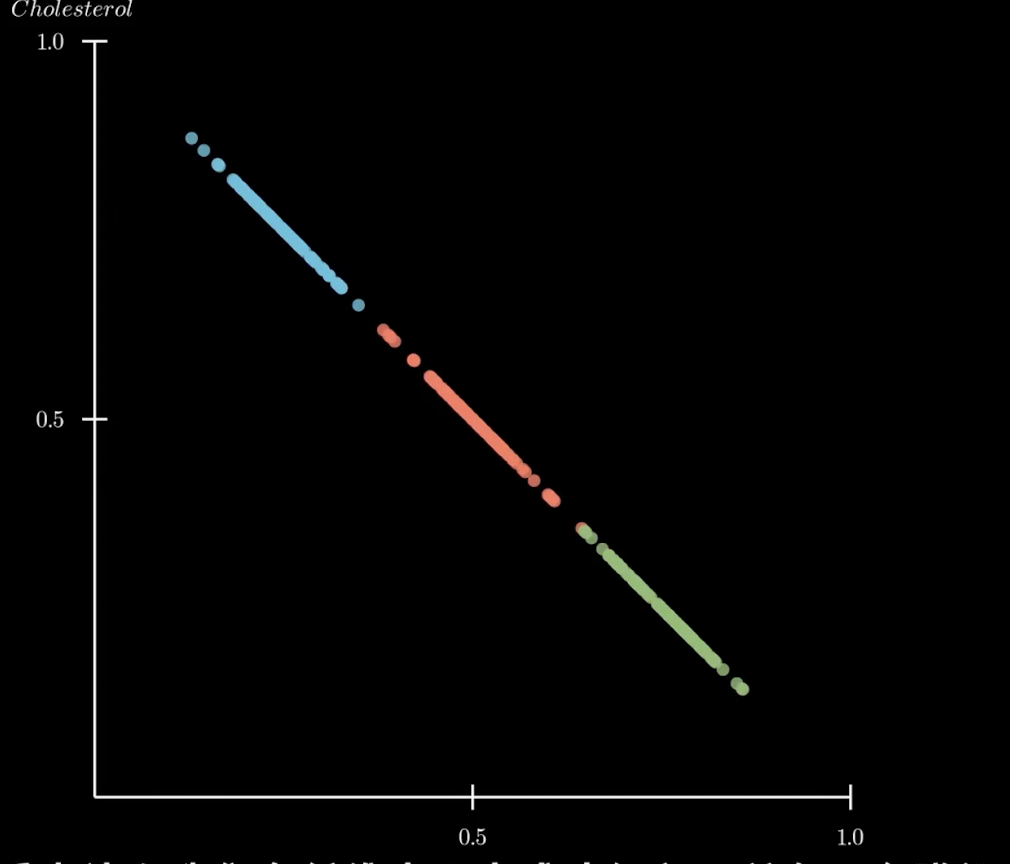

Figure 10 step3

*Source: Screenshot from “Latent Space Visualisation: PCA, t-SNE, UMAP | Deep Learning Animated” by Deepia, YouTube.https://www.youtube.com/watch?v=o_cAOa5fMhE*

This process clearly shows what a “principal component” is and why it matters in data analysis. The concept of eigenvalues mentioned in the video is also explained particularly well in Essence of Linear Algebra, which could help students connect the animation back to the underlying linear algebra meaning.

## 2.4 Clustering: Intuitive Plots and the Link Back to PCA

For clustering (apologies for the Chinese characters in the plots, since they are from a translated edition), I find the plots from Sebastian Raschka’s Python Machine Learning very intuitive for beginners. These plots provide a clear illustration of how changing the dimensional representation of data can simplify structure without changing the underlying relationships. By mapping the original data into a higher-dimensional space, patterns that are not linearly separable in the original space become easier to separate. Importantly, this transformation does not change the data itself, but rather changes how the data are represented and viewed.

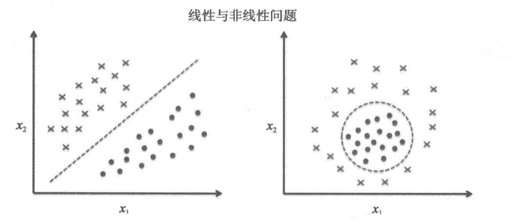

Figure 11: Cluster1

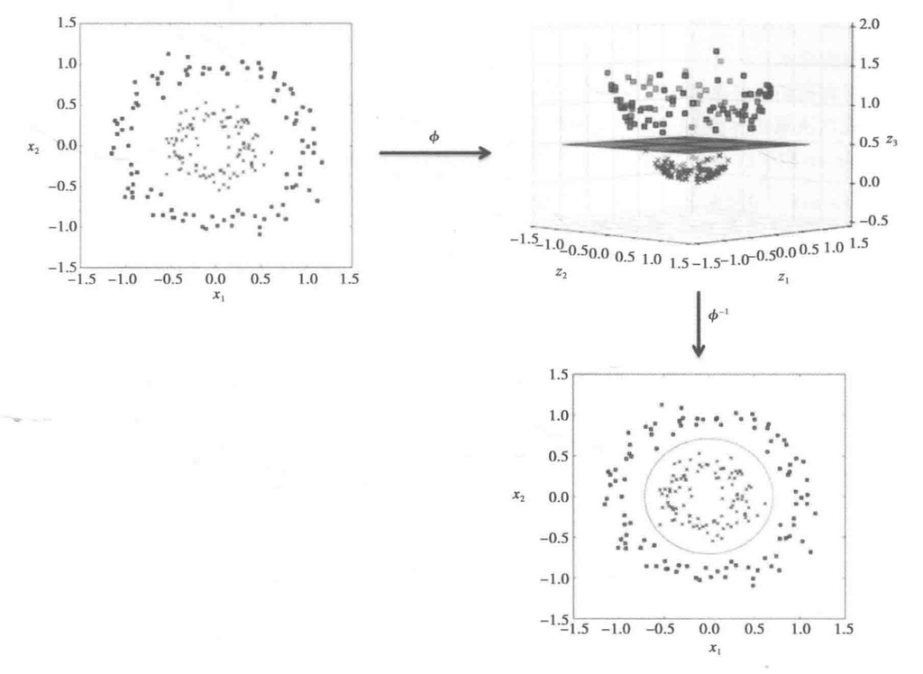

Figure 12: Cluster2

*Source: Raschka, S. (2015). Python Machine Learning. Packt Publishing.*

From this perspective, students can clearly see that what makes clustering possible in these examples is not a more complex algorithm, but an appropriate treatment of data dimensions. This reinforces the idea that many analytical methods operate by transforming the representation of data so that meaningful structure becomes more explicit. Such plots help students connect dimensionality, representation, and analytical goals in an intuitive way.

In addition, showing different PCA results side-by-side can help connect clustering back to PCA, reinforcing that these methods are related through the idea of changing the basis / representation.

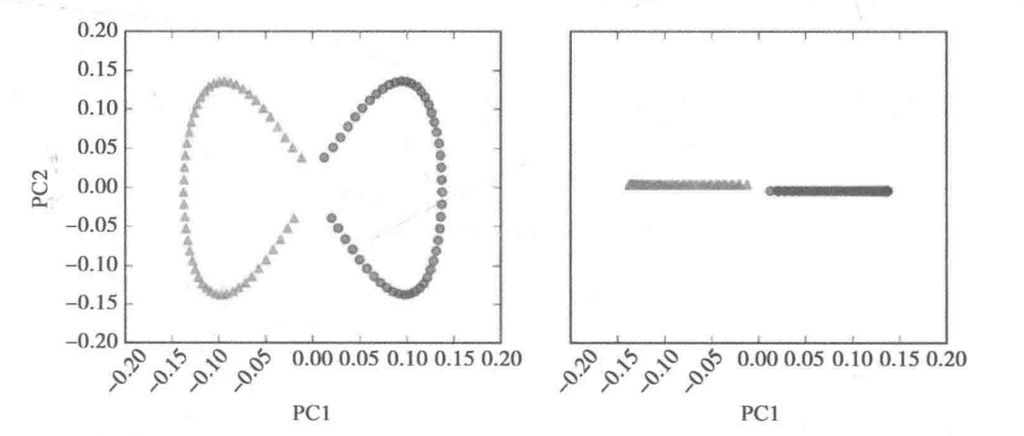

Figure 13: Cluster & PCA

*Source: Raschka, S. (2015). Python Machine Learning. Packt Publishing.*

# 3 Conclusion

Overall, what I am trying to emphasize is that the relationships among these methods and what each method is doing to the dataset need to be integrated more explicitly. This can be achieved through plots, or through explanations that are less purely statistical and more grounded in intuitive structure, while still echoing across topics. In other words, it may be more effective to build a coherent system of ideas rather than presenting many methods which made these methods look like separated tools, and in my view this system should start from understanding relationships.

Methods give us hints for solving tricky analytical problems, so the context should come first and should be explained thoroughly. The current integration of topics can work well for students who already have some basic knowledge, but it may be a little bit difficult to understand for beginners. Given the limited time and number of lessons, additional resources on basic linear algebra ideas and the overall conceptual structure could be provided via Moodle or a GitHub page as homework or pre-recorded material, with key concepts highlighted again in class.